# README

Abdullah Aydogan

February 1, 2020

This page presents the solution for Coursera’s Practical Machine Learning Course Project.

First load the necessary packages and the datasets, including the training and the testing data.

```r
library(caret)
```

```r
library(ggplot2)
library(tidyverse)
training<-read.csv("pml-training.csv")
testing<-read.csv("pml-testing.csv")
```

Visually examined the data and found out several incidence of NAs in many variables.

```r
table(training$classe)
```

```
##
##    A    B    C    D    E
## 5580 3797 3422 3216 3607
```

```r
#head(training)
```

Hence decided to limit the analysis to the set of variables with few(or none) NAs.

```r
colnames(training)
```

```
##   [1] "X"                        "user_name"
##   [3] "raw_timestamp_part_1"     "raw_timestamp_part_2"
##   [5] "cvtd_timestamp"           "new_window"
##   [7] "num_window"               "roll_belt"
##   [9] "pitch_belt"               "yaw_belt"
##  [11] "total_accel_belt"         "kurtosis_roll_belt"
##  [13] "kurtosis_picth_belt"      "kurtosis_yaw_belt"
##  [15] "skewness_roll_belt"       "skewness_roll_belt.1"
##  [17] "skewness_yaw_belt"        "max_roll_belt"
##  [19] "max_picth_belt"           "max_yaw_belt"
##  [21] "min_roll_belt"            "min_pitch_belt"
##  [23] "min_yaw_belt"             "amplitude_roll_belt"
##  [25] "amplitude_pitch_belt"     "amplitude_yaw_belt"
##  [27] "var_total_accel_belt"     "avg_roll_belt"
##  [29] "stddev_roll_belt"         "var_roll_belt"
```

[output cut: 65 more lines]

```r
#head(training[,c(8:11, 37:49, 60:68, 84:86, 102, 113:124, 140, 151:160)])
class(training$classe)
```

```
## [1] "factor"
```

trainingA: training set without the variables with none or few observations.

```r
trainingA<-training[,c(8:11, 37:49, 60:68, 84:86, 102, 113:124, 140, 151:160)]
```

Partition the data in terms of training and test set (validation set). trainingAB: training testingAB: validation

```r
inTrain <- createDataPartition(y=trainingA$classe,p=0.7, list=FALSE)
trainingAB <- trainingA[inTrain,]
testingAB<- trainingA[-inTrain,]
dim(trainingAB)
```

```
## [1] 13737    53
```

```r
dim(testingAB)
```

```
## [1] 5885   53
```

```r
table(trainingAB$classe)
```

```
##
##    A    B    C    D    E
## 3906 2658 2396 2252 2525
```

```r
table(testingAB$classe)
```

```
##
##    A    B    C    D    E
## 1674 1139 1026  964 1082
```

Due to the excessive duration of the processing, I used parallel processing feature.

```r
#Parallel processing
#install.packages("parallel")
library(parallel)
#install.packages("doParallel")
library(doParallel)
cluster<- makeCluster(detectCores()-1)
registerDoParallel(cluster)
```

Used cross validation with n=5

```r
fitControl<-trainControl(method="cv", number=5, allowParallel = TRUE)
```

Data reduction: In order to decide which variables matter most overall, wanted to do the analysis on a small random sample of the data (10 percent of the data). I will select the top 10 most important variable for the final analysis. I will apply random forest method.

```r
############
inTrain <- createDataPartition(y=trainingAB$classe,p=0.10, list=FALSE)
trainingABC<-trainingAB[inTrain,]
#Random Forests
library(randomForest)
modFit<-train(classe~., data=trainingABC,method="rf", trControl=fitControl)
modFit
```

```
## Random Forest
##
## 1376 samples
##   52 predictor
##    5 classes: 'A', 'B', 'C', 'D', 'E'
##
## No pre-processing
## Resampling: Cross-Validated (5 fold)
## Summary of sample sizes: 1101, 1100, 1102, 1100, 1101
## Resampling results across tuning parameters:
##
##   mtry  Accuracy   Kappa
##    2    0.8968005  0.8693975
##   27    0.9033513  0.8777456
##   52    0.8938887  0.8657769
##
## Accuracy was used to select the optimal model using the largest value.
## The final value used for the model was mtry = 27.
```

```r
getTree(modFit$finalModel, k=2)
```

[output not shown]

[output cut: 251 more lines]

Below are the most imortant variables in the Random Forest model.

```r
varImp(modFit)
```

```
## rf variable importance
##
##   only 20 most important variables shown (out of 52)
##
##                      Overall
## roll_belt             100.00
## pitch_forearm          73.21
## magnet_dumbbell_y      50.09
## yaw_belt               47.87
## magnet_dumbbell_z      41.67
## pitch_belt             28.39
## roll_forearm           21.65
## accel_forearm_x        20.03
## accel_dumbbell_y       19.87
## roll_dumbbell          19.87
## accel_belt_z           19.86
## magnet_dumbbell_x      18.85
## magnet_belt_y          17.96
## gyros_dumbbell_y       16.24
## magnet_belt_z          15.74
## magnet_arm_x           15.49
## roll_arm               14.92
## total_accel_dumbbell   12.52
## yaw_dumbbell           11.12
## magnet_forearm_z       10.54
```

Now I will drop the rest of the variables which are relatively less significant. Hence I will regenerate the training and testing sets based on this data reduction process.

```r
colnames(trainingAB)
```

```
##  [1] "roll_belt"            "pitch_belt"           "yaw_belt"
##  [4] "total_accel_belt"     "gyros_belt_x"         "gyros_belt_y"
##  [7] "gyros_belt_z"         "accel_belt_x"         "accel_belt_y"
## [10] "accel_belt_z"         "magnet_belt_x"        "magnet_belt_y"
## [13] "magnet_belt_z"        "roll_arm"             "pitch_arm"
## [16] "yaw_arm"              "total_accel_arm"      "gyros_arm_x"
## [19] "gyros_arm_y"          "gyros_arm_z"          "accel_arm_x"
## [22] "accel_arm_y"          "accel_arm_z"          "magnet_arm_x"
## [25] "magnet_arm_y"         "magnet_arm_z"         "roll_dumbbell"
## [28] "pitch_dumbbell"       "yaw_dumbbell"         "total_accel_dumbbell"
## [31] "gyros_dumbbell_x"     "gyros_dumbbell_y"     "gyros_dumbbell_z"
## [34] "accel_dumbbell_x"     "accel_dumbbell_y"     "accel_dumbbell_z"
## [37] "magnet_dumbbell_x"    "magnet_dumbbell_y"    "magnet_dumbbell_z"
## [40] "roll_forearm"         "pitch_forearm"        "yaw_forearm"
## [43] "total_accel_forearm"  "gyros_forearm_x"      "gyros_forearm_y"
## [46] "gyros_forearm_z"      "accel_forearm_x"      "accel_forearm_y"
## [49] "accel_forearm_z"      "magnet_forearm_x"     "magnet_forearm_y"
## [52] "magnet_forearm_z"     "classe"
```

```r
significant10 <- cbind(name = rownames(varImp(modFit)[[1]]), value = varImp(modFit)[[1]])
variables <- as.character(significant10[order(significant10[,2], decreasing = T),][1:10,1])
variables <- c(variables, "classe")
trainingAB <- trainingAB[variables]
testingAB <- testingAB[variables]
colnames(trainingAB)
```

```
##  [1] "roll_belt"         "pitch_forearm"     "magnet_dumbbell_y"
##  [4] "yaw_belt"          "magnet_dumbbell_z" "pitch_belt"
##  [7] "roll_forearm"      "accel_forearm_x"   "accel_dumbbell_y"
## [10] "roll_dumbbell"     "classe"
```

```r
colnames(testingAB)
```

```
##  [1] "roll_belt"         "pitch_forearm"     "magnet_dumbbell_y"
##  [4] "yaw_belt"          "magnet_dumbbell_z" "pitch_belt"
##  [7] "roll_forearm"      "accel_forearm_x"   "accel_dumbbell_y"
## [10] "roll_dumbbell"     "classe"
```

Now let’s check if there is excessive multicollinearity issue among the predictors.

```r
head(trainingAB)
```

|  | roll_belt | pitch_forearm | magnet_dumbbell_y | yaw_belt | magnet_dumbbell_z | pitch_belt | roll_forearm | accel_forearm_x | accel_dumbbell_y | roll_dumbbell | classe |
| --- | --- | --- | --- | --- | --- | --- | --- | --- | --- | --- | --- |
| 1 | 1.41 | -63.9 | 293 | -94.4 | -65 | 8.07 | 28.4 | 192 | 47 | 13.05217 | A |
| 2 | 1.41 | -63.9 | 296 | -94.4 | -64 | 8.07 | 28.3 | 192 | 47 | 13.13074 | A |
| 6 | 1.45 | -63.9 | 294 | -94.4 | -66 | 8.06 | 27.9 | 193 | 48 | 13.38246 | A |
| 8 | 1.42 | -63.8 | 300 | -94.4 | -74 | 8.13 | 27.8 | 193 | 46 | 12.75083 | A |
| 10 | 1.45 | -63.8 | 291 | -94.4 | -69 | 8.17 | 27.7 | 190 | 48 | 13.33034 | A |
| 12 | 1.43 | -63.8 | 291 | -94.4 | -65 | 8.18 | 27.5 | 191 | 47 | 13.10321 | A |

```r
cor(trainingAB[,1:10])
```

```
##                    roll_belt pitch_forearm magnet_dumbbell_y    yaw_belt
## roll_belt          1.0000000    0.17796920       -0.28548663  0.81321734
## pitch_forearm      0.1779692    1.00000000       -0.15659033 -0.03125725
## magnet_dumbbell_y -0.2854866   -0.15659033        1.00000000 -0.03139147
## yaw_belt           0.8132173   -0.03125725       -0.03139147  1.00000000
## magnet_dumbbell_z -0.4986718   -0.17504896        0.25970286 -0.21178126
## pitch_belt        -0.2127941    0.25877688       -0.36574149 -0.69726876
## roll_forearm      -0.1524736   -0.05785758       -0.16973841 -0.18122114
## accel_forearm_x   -0.4905101   -0.47766813       -0.16102601 -0.39323374
## accel_dumbbell_y  -0.2664817   -0.24747028        0.49467737  0.05245824
## roll_dumbbell     -0.1250333   -0.10867837        0.41240187  0.09680394
##                   magnet_dumbbell_z pitch_belt roll_forearm
## roll_belt               -0.49867183 -0.2127941  -0.15247362
## pitch_forearm           -0.17504896  0.2587769  -0.05785758
## magnet_dumbbell_y        0.25970286 -0.3657415  -0.16973841
## yaw_belt                -0.21178126 -0.6972688  -0.18122114
## magnet_dumbbell_z        1.00000000 -0.2638536  -0.04639391
## pitch_belt              -0.26385361  1.0000000   0.14456257
## roll_forearm            -0.04639391  0.1445626   1.00000000
## accel_forearm_x          0.25066518  0.1234141   0.29677265
## accel_dumbbell_y         0.23185519 -0.4530325   0.13314640
## roll_dumbbell            0.13848829 -0.3498106  -0.02777767
##                   accel_forearm_x accel_dumbbell_y roll_dumbbell
## roll_belt            -0.490510061      -0.26648171  -0.125033348
## pitch_forearm        -0.477668133      -0.24747028  -0.108678374
## magnet_dumbbell_y    -0.161026011       0.49467737   0.412401870
## yaw_belt             -0.393233743       0.05245824   0.096803935
## magnet_dumbbell_z     0.250665179       0.23185519   0.138488292
## pitch_belt            0.123414094      -0.45303253  -0.349810637
## roll_forearm          0.296772654       0.13314640  -0.027777671
## accel_forearm_x       1.000000000       0.16750094   0.001619838
## accel_dumbbell_y      0.167500941       1.00000000   0.718888481
## roll_dumbbell         0.001619838       0.71888848   1.000000000
```

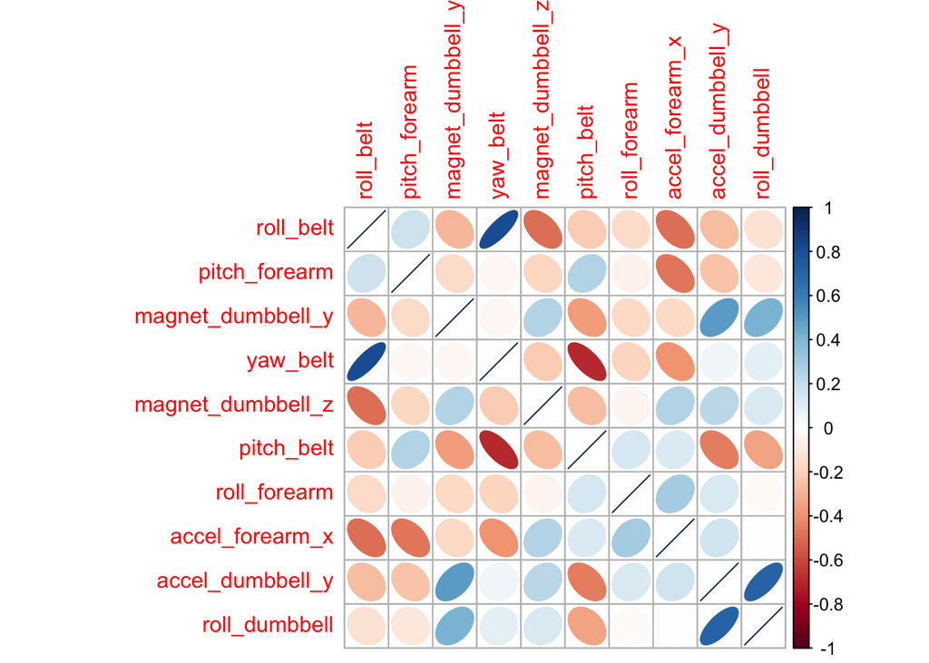

```r
#install.packages("corrplot")
library(corrplot)
corrplot(cor(trainingAB[,1:10]), method="ellipse")
```

Now we can run the final random forest model and then stop the parallel processing as we no longer need to run.

```r
modFit<-train(classe~., data=trainingAB,method="rf", trControl=fitControl)
stopCluster(cluster)
registerDoSEQ()
```

Here is the model

```r
modFit
```

```
## Random Forest
##
## 13737 samples
##    10 predictor
##     5 classes: 'A', 'B', 'C', 'D', 'E'
##
## No pre-processing
## Resampling: Cross-Validated (5 fold)
## Summary of sample sizes: 10988, 10991, 10989, 10989, 10991
## Resampling results across tuning parameters:
##
##   mtry  Accuracy   Kappa
##    2    0.9853677  0.9814929
##    6    0.9852221  0.9813096
##   10    0.9793981  0.9739453
##
## Accuracy was used to select the optimal model using the largest value.
## The final value used for the model was mtry = 2.
```

```r
getTree(modFit$finalModel, k=2)
```

[output not shown]

[output cut: 1713 more lines]

```r
modFit$resample
```

| Accuracy | Kappa | Resample |
| --- | --- | --- |
| 0.9876319 | 0.9843575 | Fold1 |
| 0.9817917 | 0.9769681 | Fold2 |
| 0.9879825 | 0.9847995 | Fold5 |
| 0.9828967 | 0.9783705 | Fold4 |
| 0.9865357 | 0.9829689 | Fold3 |

```r
confusionMatrix.train(modFit)
```

```
## Cross-Validated (5 fold) Confusion Matrix
##
## (entries are percentual average cell counts across resamples)
##
##           Reference
## Prediction    A    B    C    D    E
##          A 28.2  0.2  0.0  0.0  0.0
##          B  0.1 18.8  0.2  0.0  0.1
##          C  0.1  0.3 17.1  0.2  0.0
##          D  0.0  0.1  0.1 16.2  0.1
##          E  0.0  0.0  0.0  0.0 18.2
##
##  Accuracy (average) : 0.9854
```

Here is the predictions.

```r
pred<-predict(modFit, testingAB)
testingAB$predRight<-pred==testingAB$classe
table(pred, testingAB$classe)
```

```
##
## pred    A    B    C    D    E
##    A 1663   12    1    0    0
##    B    7 1112    8    0    3
##    C    3   14 1015    3    4
##    D    1    1    2  959    9
##    E    0    0    0    2 1066
```

```r
pred<-predict(modFit, testing)
pred
```

```
##  [1] B A B A A E D B A A B C B A E E A B B B
## Levels: A B C D E
```

```r
#B A B A A E D B A A B C B A E E A B B B
```

http://abdaydogan.github.io/practicalmachinelearning/index.html